# Issue #76: ITTの問題を克服するために、PSM-DIDのストラテジーを利用した推定

加藤 大貴

Latest update: 2021/07/24

パッケージのロード

```r
knitr::opts_chunk$set(
  message = FALSE,
  warning = FALSE
)

library(here)
knitr::opts_knit$set(root.dir = here())

library(xfun)
xfun::pkg_attach2(c("tidyverse", "rlist"))
xfun::pkg_attach2(c("lmtest", "sandwich", "lfe", "Formula", "fixest"))
xfun::pkg_attach2("kableExtra")

lapply(Sys.glob(file.path("script/R/functions", "*.r")), source)
```

```
## list()
```

データのロード

```r
df <- readr::read_csv(
  "data/shaped2.csv",
  col_types = cols(
    ext_credit_giving = col_double(),
    krw_credit_giving = col_double(),
    trust_politician = col_double(),
    political_pref = col_double(),
    addtax = col_double(),
    avg_welfare_tax = col_double(),
    opt_welfare_tax = col_double(),
    now_balance = col_double(),
    ideal_balance = col_double()
  )
)
```

## 寄付の税申告ファクトの整理

勤労所得もしくは総合所得において寄付の控除申告をしたかどうかをクロス集計で確認する。 勤労所得もしくは控除申告がN/Aの扱いは以下の通り

- 勤労所得もしくは総合所得が0ならば、控除申告はなしとみなす
- それ以外の場合、欠損値としてみなす（「回答したくない」と「申告していない」を区別できないから）

**メッセージ：税制改革以降のtax reportは過半数を下回る。**

```r
df %>%
  group_by(year) %>%
  summarize_at(
    vars(ext_benefit_t, ext_benefit_tl),
    list(
      Yes = ~sum((. == 1), na.rm = TRUE),
      No = ~sum((. == 0), na.rm = TRUE)
    )
  ) %>%
  kable(
    col.names = c(
      "Year", "Labor inc", "Labor and Total inc",
      "Labor inc", "Labor and Total inc"
    ),
    align = "lcccc"
  ) %>%
  add_header_above(c("", "Tax report" = 2, "No tax report" = 2)) %>%
  kable_styling()
```

| Year | Tax report Labor inc | Tax report Labor and Total inc | No tax report Labor inc | No tax report Labor and Total inc |
| --- | --- | --- | --- | --- |
| 2012 | 73 | 1015 | 1007 | 985 |
| 2013 | 84 | 1033 | 994 | 978 |
| 2014 | 19 | 721 | 1021 | 988 |
| 2015 | 25 | 785 | 1082 | 1049 |
| 2016 | 29 | 787 | 1072 | 1031 |
| 2017 | 28 | 851 | 1122 | 1076 |
| 2018 | 17 | 703 | 172 | 170 |

以下の就業形態に関する変数を用いる

- `p_aa005`：雇用形態（1=常用職2=臨時職日雇い3=自営業4=無給家族従事者）
- `paa008`：産業
  - 農業
  - 林業や漁業
  - 鉱業
  - 製造業
  - 電気、ガスおよび水道事業
  - 下水∙、廃棄物処理、原料再生および環境ボクウォンオプ
  - 建設業
  - 卸売や小売業
  - 運輸業
  - 宿泊と飲食店業
  - 出版、映像、放送通信や情報サービス業
  - 金融および保険業
  - 不動産業及び賃貸業
  - 専門科学および技術サービス業
  - 事業施設管理および事業支援サービス業
  - 公共行政、国防や、社会保障、行政
  - 教育サービス業
  - 保険業や社会福祉サービス業
  - 芸術、スポーツや余暇関連サービス業
  - 協会や団体、修理および個人サービス業
  - 世帯内雇用活動と違って分類されていない者が消費、生産活動
  - 国際および外国機関

`p_aa005`で常用職かどうかのダミー変数を作成する。`paa008`は共変量としてコントロールする。

employeeかどうかで控除申請に差があるかどうかを記述統計で確認する。 初めに労働所得で控除申請している比率を示す。

**メッセージ：労働者の方がtax reportする比率が自営業者よりも高い**

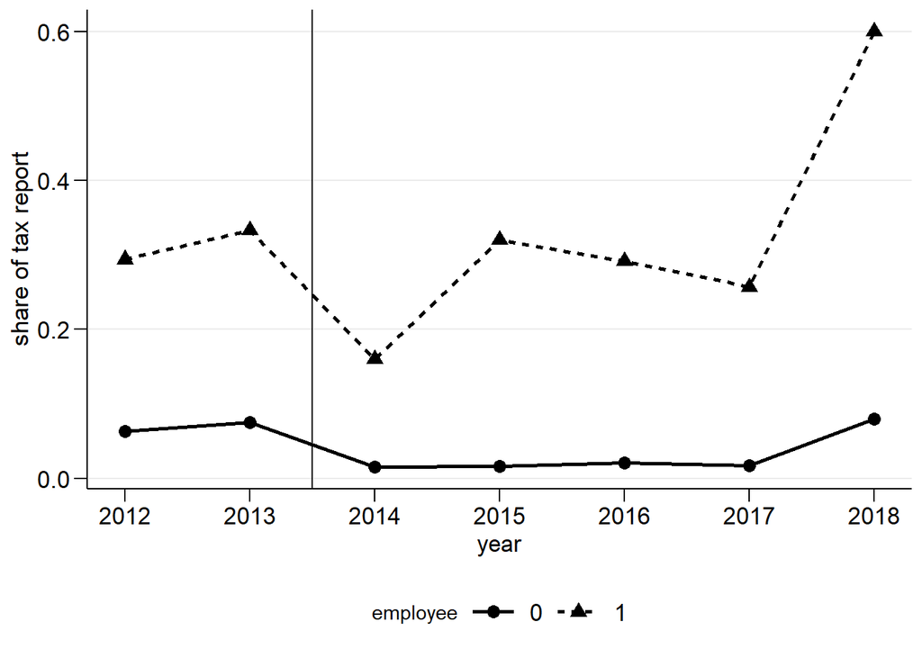

```r
df %>%
  dplyr::filter(!is.na(employee)) %>%
  group_by(year, employee) %>%
  summarize_at(vars(ext_benefit_t), list(~ mean(., na.rm = TRUE))) %>%
  mutate(employee = factor(employee)) %>%
  ggplot(aes(x = year, y = ext_benefit_t, group = employee)) +
  geom_point(aes(shape = employee), color = "black", size = 3) +
  geom_line(aes(linetype = employee), size = 1) +
  geom_vline(aes(xintercept = 2013.5)) +
  scale_x_continuous(breaks = seq(2012, 2018, 1)) +
  labs(y = "share of tax report") +
  ggtemp()
```

次に、総合所得もしくは労働所得の項目で控除申請しているかどうかの比率を示す

この図のメッセージ

- 労働者の申請比率はほぼ100%に近くなる = 総合所得で税控除を申請している
- 自営業者の申請比率は変化していない

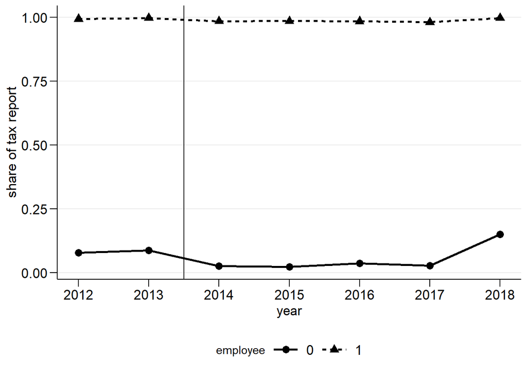

```r
df %>%
  dplyr::filter(!is.na(employee)) %>%
  group_by(year, employee) %>%
  summarize_at(vars(ext_benefit_tl), list(~ mean(., na.rm = TRUE))) %>%
  mutate(employee = factor(employee)) %>%
  ggplot(aes(x = year, y = ext_benefit_tl, group = employee)) +
  geom_point(aes(shape = employee), color = "black", size = 3) +
  geom_line(aes(linetype = employee), size = 1) +
  geom_vline(aes(xintercept = 2013.5)) +
  scale_x_continuous(breaks = seq(2012, 2018, 1)) +
  labs(y = "share of tax report") +
  ggtemp()
```

## Simple Panel Data Model

Panel IVを使う意義として、スタンダードな固定効果モデルの推定結果を示す。 推定モデルは

$$\log g_{it}
= \alpha_{2i} + \delta D_{it} \log p_{it} + X_{it} \beta_2
+ \lambda_{2t} + \epsilon_{it}$$

統計的推論では個人レベルのクラスター標準誤差を使用する。

Simple panel data modelのメッセージ

- 全体の弾力性とintensive-margin elasticityはITTの時よりも過大推定
- Extensive-margin elasticityはITTの弾性値の時よりも過小推定
- Tax reportが絡むと弾性値が変わるので、「reportした人とそうでない人の異質性」か「観察不可能な要因との交絡」が考えられる

```r
simplemodel <- list(
  overall = list(y = log_total_g ~ ., data = subset(df, year <= 2017)),
  ext = list(y = i_ext_giving ~ ., data = subset(df, year <= 2017)),
  ext = list(
    y = log_total_g ~ .,
    data = subset(df, i_ext_giving == 1 & year <= 2017)
  )
)

est_simplemodel <- simplemodel %>%
  purrr::map(~ fit_fixest(
    y = .$y,
    x = ~ log_price:ext_benefit_tl + log_pinc_all + age + sqage +
      factor(year):factor(educ) + factor(year):factor(gender) +
      factor(year):factor(indust),
    fixef = ~year + pid, cluster = ~pid, data = .$data
  )) %>%
  regtab_fixest(
    keep_coef = "log_price:ext_benefit_tl",
    label_coef = list("log_price:ext_benefit_tl" = "Report x log(first price)")
  )

simplemodel_tab <- tribble(
  ~vars, ~stat, ~reg1, ~reg2, ~reg3,
  "Individual and time FE", "vars", "Y", "Y", "Y",
  "log(income)", "vars", "Y", "Y", "Y",
  "Age", "vars", "Y", "Y", "Y",
  "Year x Education", "vars", "Y", "Y", "Y",
  "Year x Gender", "vars", "Y", "Y", "Y",
  "Year x Resident Area", "vars", "Y", "Y", "Y",
  "Year x Dummy of industry", "vars", "Y", "Y", "Y"
)

est_simplemodel %>%
  regtab_addline(list(simplemodel_tab)) %>%
  mutate(vars = if_else(stat == "se", "", vars)) %>%
  dplyr::select(-stat) %>%
  kable(
    col.names = c("", "Overall", "Extensive", "Intensive"),
    align = "lccc"
  ) %>%
  kable_styling()
```

|  | Overall | Extensive | Intensive |
| --- | --- | --- | --- |
| Report x log(first price) | -4.108*** | -0.879*** | -1.524*** |
|  | (0.595) | (0.135) | (0.400) |
| Individual and time FE | Y | Y | Y |
| log(income) | Y | Y | Y |
| Age | Y | Y | Y |
| Year x Education | Y | Y | Y |
| Year x Gender | Y | Y | Y |
| Year x Resident Area | Y | Y | Y |
| Year x Dummy of industry | Y | Y | Y |
| N | 10964 | 10964 | 4619 |
| Adjusted R-squared | 0.568 | 0.516 | 0.727 |

## Panel IV: Endog var is tax report x giving price and IV is employed dummy.

$\log g_{it}$を寄付の対数値、$\ln p_{it}$は寄付の相対価格（first price）とする。 $D_{it}$はtax reportのダミー変数とする。 Panel IVの推定において、個人固定効果$\alpha$と時間固定効果$\lambda$はコントロールする。 仮説検定では、個人レベルでクラスターした標準誤差を使用する。

Second stage:

$$\log g_{it}
= \alpha_{2i} + \delta D_{it} \log p_{it} + X_{it} \beta_2
+ \lambda_{2t} + \epsilon_{it}$$

First stage:

$$D_{it} \log p_{it}
= \alpha_{1i} + \gamma \text{Employed}_{it} + X_{it} \beta_1
+ \lambda_{1t} + \eta_{it}$$

Panel first-stageのメッセージ

- 自営業者より労働者はtax reportをして寄付の相対価格を下げている
- 個人固定効果をコントロールしても統計的に有意（F-値は最低でも70）

```r
xlist <- list(
  ~ employee,
  ~ employee + log_pinc_all + age + sqage +
    factor(year):factor(educ) + factor(year):factor(gender),
  ~ employee + log_pinc_all + age + sqage +
    factor(year):factor(educ) + factor(year):factor(gender) +
    factor(year):factor(indust)
)

xlist_tab <- tribble(
  ~vars, ~stat, ~reg1, ~reg2, ~reg3,
  "Time FE", "vars", "Y", "Y", "Y",
  "log(income)", "vars", "N", "Y", "Y",
  "Age", "vars", "N", "Y", "Y",
  "Year x Education", "vars", "N", "Y", "Y",
  "Year x Gender", "vars", "N", "Y", "Y",
  "Year x Resident Area", "vars", "N", "Y", "Y",
  "Year x Dummy of industry", "vars", "N", "N", "Y"
)

est_xreport1 <- xlist %>%
  purrr::map(~ fit_fixest(
    y = int_price_benefit ~ ., x = .,
    fixef = ~ year, cluster = ~ pid,
    data = subset(df, year <= 2017)
  ))

est_xreport2 <- xlist %>%
  purrr::map(~ fit_fixest(
    y = int_price_benefit ~ ., x = .,
    fixef = ~year + pid, cluster = ~pid,
    data = subset(df, year <= 2017)
  ))

list(est_xreport1, est_xreport2) %>%
  purrr::map(~ regtab_fixest(., keep_coef = "employee")) %>%
  purrr::map(~ regtab_addline(., list(xlist_tab))) %>%
  reduce(full_join, by = c("vars", "stat")) %>%
  mutate(vars = if_else(stat == "se", "", vars)) %>%
  dplyr::select(-stat) %>%
  kable(
    col.names = c("", sprintf("(%1d)", seq_len(length(xlist) * 2))),
    align = "lcccccc"
  ) %>%
  add_header_above(c("", "w/o individual FE" = 3, "w/ individual FE" = 3)) %>%
  kable_styling()
```

w/o individual FE

w/ individual FE

employee

-0.182***

-0.129***

-0.126***

-0.098***

-0.091***

-0.084***

(0.001)

(0.005)

(0.005)

(0.010)

(0.010)

(0.010)

Time FE

Y

Y

Y

Y

Y

Y

log(income)

N

Y

Y

N

Y

Y

Age

N

Y

Y

N

Y

Y

Year x Education

N

Y

Y

N

Y

Y

Year x Gender

N

Y

Y

N

Y

Y

Year x Resident Area

N

Y

Y

N

Y

Y

Year x Dummy of industry

N

N

Y

N

N

Y

N

11087

11085

10942

11087

11085

10942

Adjusted R-squared

0.810

0.854

0.866

0.854

0.869

0.883

Panel IVの推定結果のメッセージ

- 弾力性は10%。1%の相対価格の上昇が寄付額を10%程度下げる
- ITTで考えていたよりもかなり弾力的な結果となる

```r
ivest_xreport1 <- xlist %>%
  purrr::map(~ fit_fixest(
    y = log_total_g ~ .,
    x = update(., ~ . - employee),
    z = int_price_benefit ~ employee,
    fixef = ~ year, cluster = ~ pid,
    data = subset(df, year <= 2017)
  ))

ivest_xreport2 <- xlist %>%
  purrr::map(~ fit_fixest(
    y = log_total_g ~ .,
    x = update(., ~ . - employee),
    z = int_price_benefit ~ employee,
    fixef = ~year + pid, cluster = ~ pid,
    data = subset(df, year <= 2017)
  ))

ivfstat <- list(ivest_xreport1, ivest_xreport2) %>%
  purrr::map_depth(2, ~ fitstat(., ~ ivwald)$ivwald1$stat) %>%
  purrr::map(~ as_vector(.)) %>%
  as_vector() %>%
  matrix(nrow = 1) %>%
  data.frame() %>%
  setNames(paste0("reg", seq_len(length(xlist) * 2)))

ivfstat_tab <- ivfstat %>%
  mutate_all(list(~ sprintf("%1.3f", .))) %>%
  mutate(vars = "Fstat of IV", stat = "vars")

xlist_duptab <- xlist_tab %>%
  full_join(xlist_tab, by = c("vars", "stat")) %>%
  setNames(c("vars", "stat", paste0("reg", seq_len(length(xlist) * 2))))

list(ivest_xreport1, ivest_xreport2) %>%
  flatten() %>%
  regtab_fixest(
    keep_coef = "int_price_benefit",
    label_coef = list("fit_int_price_benefit" = "Report x log(first price)")
  ) %>%
  regtab_addline(list(ivfstat_tab, xlist_duptab)) %>%
  mutate(vars = if_else(stat == "se", "", vars)) %>%
  dplyr::select(-stat) %>%
  kable(
    col.names = c("", sprintf("(%1d)", seq_len(length(xlist) * 2))),
    align = "lcccccc"
  ) %>%
  add_header_above(c("", "w/o individual FE" = 3, "w/ individual FE" = 3)) %>%
  kable_styling()
```

w/o individual FE

w/ individual FE

Report x log(first price)

-11.115***

-11.501***

-9.909***

-8.680***

-9.265***

-10.434***

(0.333)

(0.855)

(0.991)

(1.971)

(2.295)

(2.519)

Fstat of IV

29639.292

757.364

627.749

106.708

91.591

72.246

Time FE

Y

Y

Y

Y

Y

Y

log(income)

N

Y

Y

N

Y

Y

Age

N

Y

Y

N

Y

Y

Year x Education

N

Y

Y

N

Y

Y

Year x Gender

N

Y

Y

N

Y

Y

Year x Resident Area

N

Y

Y

N

Y

Y

Year x Dummy of industry

N

N

Y

N

N

Y

N

11087

11085

10942

11087

11085

10942

Adjusted R-squared

0.211

0.226

0.243

0.557

0.559

0.558

extensive-margin elasticityのPanel IVの結果

- 価格1%上昇によって、寄付する確率を1%下げる
- この結果はITTで考えた推定結果と非常に似ている。

```r
ivest_xreport1_ext <- xlist %>%
  purrr::map(~ fit_fixest(
    y = i_ext_giving ~ .,
    x = update(., ~ . - employee),
    z = int_price_benefit ~ employee,
    fixef = ~year, cluster = ~pid,
    data = subset(df, year <= 2017)
  ))

ivest_xreport2_ext <- xlist %>%
  purrr::map(~ fit_fixest(
    y = i_ext_giving ~ .,
    x = update(., ~ . - employee),
    z = int_price_benefit ~ employee,
    fixef = ~ year + pid, cluster = ~pid,
    data = subset(df, year <= 2017)
  ))

waldtest_ext <- list(ivest_xreport1_ext, ivest_xreport2_ext) %>%
  purrr::map_depth(2, ~ tibble(
    vars = "Implied price elasticity",
    coef = coef(.)["fit_int_price_benefit"],
    se = fixest::se(.)["fit_int_price_benefit"],
    invmu = 1 / mean(model.matrix(., type = "lhs")),
    p = fixest::pvalue(.)["fit_int_price_benefit"]
  )) %>%
  purrr::map_depth(2, function(x)
    x %>%
      mutate(
        coef = case_when(
          p <= .01 ~ sprintf("%1.3f***", coef / invmu),
          p <= .05 ~ sprintf("%1.3f**", coef / invmu),
          p <= .1 ~ sprintf("%1.3f*", coef / invmu),
          TRUE ~ sprintf("%1.3f", coef / invmu)
        ),
        se = sprintf("(%1.3f)", se / invmu)
      ) %>%
      dplyr::select(-p, -invmu) %>%
      pivot_longer(-vars, names_to = "stat", values_to = "val")
  ) %>%
  purrr::map(~ reduce(., full_join, by = c("vars", "stat"))) %>%
  reduce(full_join, by = c("vars", "stat")) %>%
  setNames(c("vars", "stat", paste0("reg", seq_len(length(xlist) * 2)))) %>%
  bind_rows(
    c(vars = "", stat = "", reg1 = "", reg2 = "",
      reg3 = "", reg4 = "", reg5 = "", reg6 = ""),
    .
  )

ivfstat_ext <- list(ivest_xreport1_ext, ivest_xreport2_ext) %>%
  purrr::map_depth(2, ~ fitstat(., ~ ivwald)$ivwald1$stat) %>%
  purrr::map(~ as_vector(.)) %>%
  as_vector() %>%
  matrix(nrow = 1) %>%
  data.frame() %>%
  setNames(paste0("reg", seq_len(length(xlist) * 2)))

ivfstat_ext_tab <- ivfstat_ext %>%
  mutate_all(list(~ sprintf("%1.3f", .))) %>%
  mutate(vars = "Fstat of IV", stat = "vars")

list(ivest_xreport1_ext, ivest_xreport2_ext) %>%
  flatten() %>%
  regtab_fixest(
    keep_coef = "int_price_benefit",
    label_coef = list("fit_int_price_benefit" = "Report x log(first price)")
  ) %>%
  regtab_addline(list(waldtest_ext, ivfstat_tab, xlist_duptab)) %>%
  mutate(vars = if_else(stat == "se", "", vars)) %>%
  dplyr::select(-stat) %>%
  kable(
    col.names = c("", sprintf("(%1d)", seq_len(length(xlist) * 2))),
    align = "lcccccc"
  ) %>%
  add_header_above(c("", "w/o individual FE" = 3, "w/ individual FE" = 3)) %>%
  kable_styling()
```

w/o individual FE

w/ individual FE

Report x log(first price)

-2.816***

-3.557***

-3.363***

-2.633***

-3.046***

-3.569***

(0.061)

(0.155)

(0.171)

(0.473)

(0.547)

(0.614)

Implied price elasticity

-1.186***

-1.498***

-1.417***

-1.109***

-1.283***

-1.504***

(0.026)

(0.065)

(0.072)

(0.199)

(0.231)

(0.259)

Fstat of IV

29639.292

757.364

627.749

106.708

91.591

72.246

Time FE

Y

Y

Y

Y

Y

Y

log(income)

N

Y

Y

N

Y

Y

Age

N

Y

Y

N

Y

Y

Year x Education

N

Y

Y

N

Y

Y

Year x Gender

N

Y

Y

N

Y

Y

Year x Resident Area

N

Y

Y

N

Y

Y

Year x Dummy of industry

N

N

Y

N

N

Y

N

11087

11085

10942

11087

11085

10942

Adjusted R-squared

0.262

0.262

0.281

0.488

0.483

0.477

intensive-margin elasticityのPanel IVの結果

- 個人固定効果を除くと価格の上昇が寄付の増加を促す（個人固定効果を入れていないのが原因？何らかの解釈が可能？）
- 個人固定効果を入れると統計的に非有意となる（弱操作変数の影響とは考えにくい）

```r
ivest_xreport1_int <- xlist %>%
  purrr::map(~ fit_fixest(
    y = log_total_g ~ .,
    x = update(., ~ . - employee),
    z = int_price_benefit ~ employee,
    fixef = ~year, cluster = ~pid,
    data = subset(df, i_ext_giving == 1 & year <= 2017)
  ))

ivest_xreport2_int <- xlist %>%
  purrr::map(~ fit_fixest(
    y = log_total_g ~ .,
    x = update(., ~ . - employee),
    z = int_price_benefit ~ employee,
    fixef = ~ year + pid, cluster = ~pid,
    data = subset(df, i_ext_giving == 1 & year <= 2017)
  ))

ivfstat_int <- list(ivest_xreport1_int, ivest_xreport2_int) %>%
  purrr::map_depth(2, ~ fitstat(., ~ ivwald)$ivwald1$stat) %>%
  purrr::map(~ as_vector(.)) %>%
  as_vector() %>%
  matrix(nrow = 1) %>%
  data.frame() %>%
  setNames(paste0("reg", seq_len(length(xlist) * 2)))

ivfstat_int_tab <- ivfstat_int %>%
  mutate_all(list(~ sprintf("%1.3f", .))) %>%
  mutate(vars = "Fstat of IV", stat = "vars")

list(ivest_xreport1_int, ivest_xreport2_int) %>%
  flatten() %>%
  regtab_fixest(
    keep_coef = "int_price_benefit",
    label_coef = list("fit_int_price_benefit" = "Report x log(first price)")
  ) %>%
  regtab_addline(list(ivfstat_int_tab, xlist_duptab)) %>%
  mutate(vars = if_else(stat == "se", "", vars)) %>%
  dplyr::select(-stat) %>%
  kable(
    col.names = c("", sprintf("(%1d)", seq_len(length(xlist) * 2))),
    align = "lcccccc"
  ) %>%
  add_header_above(c("", "w/o individual FE" = 3, "w/ individual FE" = 3)) %>%
  kable_styling()
```

w/o individual FE

w/ individual FE

Report x log(first price)

2.187***

6.933***

9.092***

-2.041

-1.041

0.316

(0.450)

(1.145)

(1.367)

(1.881)

(2.422)

(2.473)

Fstat of IV

6270.046

658.215

508.078

47.349

35.683

27.741

Time FE

Y

Y

Y

Y

Y

Y

log(income)

N

Y

Y

N

Y

Y

Age

N

Y

Y

N

Y

Y

Year x Education

N

Y

Y

N

Y

Y

Year x Gender

N

Y

Y

N

Y

Y

Year x Resident Area

N

Y

Y

N

Y

Y

Year x Dummy of industry

N

N

Y

N

N

Y

N

4669

4669

4611

4669

4669

4611

Adjusted R-squared

-0.015

-0.017

-0.027

0.724

0.726

0.724

## Panel IV: Endog var is tax report and IV is employed dummy.

$\log g_{it}$を寄付の対数値、$\ln p_{it}$は寄付の相対価格（first price）とする。 $D_{it}$はtax reportのダミー変数とし、first-stageの予測値を$\hat{D}_{it}$とする。 Panel IVの推定において、個人固定効果$\alpha$と時間固定効果$\lambda$はコントロールする。 仮説検定では、個人レベルでクラスターした標準誤差を使用する。

Second stage:

$$\log g_{it}
= \alpha_{2i} + \delta \hat{D}_{it} \log p_{it} + X_{it} \beta_2
+ \lambda_{2t} + \epsilon_{it}$$

First stage:

$$D_{it}
= \alpha_{1i} + \gamma \text{Employed}_{it} + X_{it} \beta_1
+ \lambda_{1t} + \eta_{it}$$

Panel first-stageのメッセージ

- 自営業者より労働者がtax reportする確率は約50%高い
- 個人固定効果をコントロールしても統計的に有意（F-値は最低でも80）

```r
est_report1 <- xlist %>%
  purrr::map(~ fit_fixest(
    y = ext_benefit_tl ~ ., x = .,
    fixef = ~ year, cluster = ~ pid,
    data = subset(df, year <= 2017)
  ))

est_report2 <- xlist %>%
  purrr::map(~ fit_fixest(
    y = ext_benefit_tl ~ ., x = .,
    fixef = ~year + pid, cluster = ~pid,
    data = subset(df, year <= 2017)
  ))

list(est_report1, est_report2) %>%
  purrr::map(~ regtab_fixest(., keep_coef = "employee")) %>%
  purrr::map(~ regtab_addline(., list(xlist_tab))) %>%
  reduce(full_join, by = c("vars", "stat")) %>%
  mutate(vars = if_else(stat == "se", "", vars)) %>%
  dplyr::select(-stat) %>%
  kable(
    col.names = c("", sprintf("(%1d)", seq_len(length(xlist) * 2))),
    align = "lcccccc"
  ) %>%
  add_header_above(c("", "w/o individual FE" = 3, "w/ individual FE" = 3)) %>%
  kable_styling()
```

w/o individual FE

w/ individual FE

employee

0.941***

0.867***

0.852***

0.508***

0.464***

0.457***

(0.004)

(0.012)

(0.014)

(0.047)

(0.049)

(0.050)

Time FE

Y

Y

Y

Y

Y

Y

log(income)

N

Y

Y

N

Y

Y

Age

N

Y

Y

N

Y

Y

Year x Education

N

Y

Y

N

Y

Y

Year x Gender

N

Y

Y

N

Y

Y

Year x Resident Area

N

Y

Y

N

Y

Y

Year x Dummy of industry

N

N

Y

N

N

Y

N

11088

11085

10942

11088

11085

10942

Adjusted R-squared

0.882

0.885

0.888

0.918

0.919

0.920

上の表の(6)の予測値を$\hat{D}_{it}$とする。

```r
df$p_ext_benefit_tl <- predict(est_report2[[3]], df)
```

Panel IVの推定結果のメッセージ

- ITTとして推定した弾性値（約1%）より若干弾力的である
- Tax reportをしていない人の価格は必ず$\log 1$であることを考えれば、納得できる結果

```r
ivest_report1 <- xlist %>%
  purrr::map(~ fit_fixest(
    y = log_total_g ~ .,
    x = update(., ~ . - employee + log_price:p_ext_benefit_tl),
    fixef = ~ year, cluster = ~ pid,
    data = subset(df, year <= 2017)
  ))

ivest_report2 <- xlist %>%
  purrr::map(~ fit_fixest(
    y = log_total_g ~ .,
    x = update(., ~ . - employee + log_price:p_ext_benefit_tl),
    fixef = ~year + pid, cluster = ~ pid,
    data = subset(df, year <= 2017)
  ))

list(ivest_report1, ivest_report2) %>%
  flatten() %>%
  regtab_fixest(
    keep_coef = "log_price",
    label_coef = list(
      "log_price:p_ext_benefit_tl" = "Propensity of Report x log(first price)"
    )
  ) %>%
  regtab_addline(list(xlist_duptab)) %>%
  mutate(vars = if_else(stat == "se", "", vars)) %>%
  dplyr::select(-stat) %>%
  kable(
    col.names = c("", sprintf("(%1d)", seq_len(length(xlist) * 2))),
    align = "lcccccc"
  ) %>%
  add_header_above(c("", "w/o individual FE" = 3, "w/ individual FE" = 3)) %>%
  kable_styling()
```

w/o individual FE

w/ individual FE

Propensity of Report x log(first price)

-7.894***

-5.935***

-5.194***

-2.364***

-1.710***

-1.603***

(0.266)

(0.459)

(0.481)

(0.401)

(0.447)

(0.466)

Time FE

Y

Y

Y

Y

Y

Y

log(income)

N

Y

Y

N

Y

Y

Age

N

Y

Y

N

Y

Y

Year x Education

N

Y

Y

N

Y

Y

Year x Gender

N

Y

Y

N

Y

Y

Year x Resident Area

N

Y

Y

N

Y

Y

Year x Dummy of industry

N

N

Y

N

N

Y

N

16946

16946

16946

16946

16946

16946

Adjusted R-squared

0.121

0.144

0.156

0.511

0.513

0.514

extensive-margin elasticityのPanel IVの結果

- ITTとして想定したベースラインの結果（-1.4 ~ -1.2%）より、非弾力的になる（0.1%）
- extensive-marginの弾力性はtax reportをしていない人に特に強い影響を与えるのか？

```r
ivest_report1_ext <- xlist %>%
  purrr::map(~ fit_fixest(
    y = i_ext_giving ~ .,
    x = update(., ~ . - employee + log_price:p_ext_benefit_tl),
    fixef = ~year, cluster = ~pid,
    data = subset(df, year <= 2017)
  ))

ivest_report2_ext <- xlist %>%
  purrr::map(~ fit_fixest(
    y = i_ext_giving ~ .,
    x = update(., ~ . - employee + log_price:p_ext_benefit_tl),
    fixef = ~ year + pid, cluster = ~pid,
    data = subset(df, year <= 2017)
  ))

waldtest_ext <- list(ivest_report1_ext, ivest_report2_ext) %>%
  purrr::map_depth(2, ~ tibble(
    vars = "Implied price elasticity",
    coef = coef(.)["log_price:p_ext_benefit_tl"],
    se = fixest::se(.)["log_price:p_ext_benefit_tl"],
    invmu = 1 / mean(model.matrix(., type = "lhs")),
    p = fixest::pvalue(.)["log_price:p_ext_benefit_tl"]
  )) %>%
  purrr::map_depth(2, function(x)
    x %>%
      mutate(
        coef = case_when(
          p <= .01 ~ sprintf("%1.3f***", coef / invmu),
          p <= .05 ~ sprintf("%1.3f**", coef / invmu),
          p <= .1 ~ sprintf("%1.3f*", coef / invmu),
          TRUE ~ sprintf("%1.3f", coef / invmu)
        ),
        se = sprintf("(%1.3f)", se / invmu)
      ) %>%
      dplyr::select(-p, -invmu) %>%
      pivot_longer(-vars, names_to = "stat", values_to = "val")
  ) %>%
  purrr::map(~ reduce(., full_join, by = c("vars", "stat"))) %>%
  reduce(full_join, by = c("vars", "stat")) %>%
  setNames(c("vars", "stat", paste0("reg", seq_len(length(xlist) * 2)))) %>%
  bind_rows(
    c(vars = "", stat = "", reg1 = "", reg2 = "",
      reg3 = "", reg4 = "", reg5 = "", reg6 = ""),
    .
  )

list(ivest_report1_ext, ivest_report2_ext) %>%
  flatten() %>%
  regtab_fixest(
    keep_coef = "log_price",
    label_coef = list(
      "log_price:p_ext_benefit_tl" = "Propensity of Report x log(first price)"
    )
  ) %>%
  regtab_addline(list(waldtest_ext, xlist_duptab)) %>%
  mutate(vars = if_else(stat == "se", "", vars)) %>%
  dplyr::select(-stat) %>%
  kable(
    col.names = c("", sprintf("(%1d)", seq_len(length(xlist) * 2))),
    align = "lcccccc"
  ) %>%
  add_header_above(c("", "w/o individual FE" = 3, "w/ individual FE" = 3)) %>%
  kable_styling()
```

w/o individual FE

w/ individual FE

Propensity of Report x log(first price)

-1.899***

-1.539***

-1.375***

-0.506***

-0.347***

-0.319***

(0.052)

(0.090)

(0.094)

(0.090)

(0.104)

(0.110)

Implied price elasticity

-0.655***

-0.530***

-0.474***

-0.174***

-0.120***

-0.110***

(0.018)

(0.031)

(0.032)

(0.031)

(0.036)

(0.038)

Time FE

Y

Y

Y

Y

Y

Y

log(income)

N

Y

Y

N

Y

Y

Age

N

Y

Y

N

Y

Y

Year x Education

N

Y

Y

N

Y

Y

Year x Gender

N

Y

Y

N

Y

Y

Year x Resident Area

N

Y

Y

N

Y

Y

Year x Dummy of industry

N

N

Y

N

N

Y

N

16946

16946

16946

16946

16946

16946

Adjusted R-squared

0.147

0.166

0.179

0.426

0.427

0.428

intensive-margin elasticityのPanel IVの結果

- 個人固定効果を加えると、ITTとして想定した弾性値（-1 ~ -0.5%）と似たような結果を取る
- Intenstive-margin elasticityはtax reportをする人に特に影響を与えるのか？

```r
ivest_report1_int <- xlist %>%
  purrr::map(~ fit_fixest(
    y = log_total_g ~ .,
    x = update(., ~ . - employee + log_price:p_ext_benefit_tl),
    fixef = ~year, cluster = ~pid,
    data = subset(df, i_ext_giving == 1 & year <= 2017)
  ))

ivest_report2_int <- xlist %>%
  purrr::map(~ fit_fixest(
    y = log_total_g ~ .,
    x = update(., ~ . - employee + log_price:p_ext_benefit_tl),
    fixef = ~ year + pid, cluster = ~pid,
    data = subset(df, i_ext_giving == 1 & year <= 2017)
  ))

list(ivest_report1_int, ivest_report2_int) %>%
  flatten() %>%
  regtab_fixest(
    keep_coef = "log_price",
    label_coef = list(
      "log_price:p_ext_benefit_tl" = "Propensity of Report x log(first price)"
    )
  ) %>%
  regtab_addline(list(xlist_duptab)) %>%
  mutate(vars = if_else(stat == "se", "", vars)) %>%
  dplyr::select(-stat) %>%
  kable(
    col.names = c("", sprintf("(%1d)", seq_len(length(xlist) * 2))),
    align = "lcccccc"
  ) %>%
  add_header_above(c("", "w/o individual FE" = 3, "w/ individual FE" = 3)) %>%
  kable_styling()
```

w/o individual FE

w/ individual FE

Propensity of Report x log(first price)

0.049

0.893**

1.151**

-1.161***

-0.947***

-0.987***

(0.326)

(0.447)

(0.486)

(0.284)

(0.318)

(0.342)

Time FE

Y

Y

Y

Y

Y

Y

log(income)

N

Y

Y

N

Y

Y

Age

N

Y

Y

N

Y

Y

Year x Education

N

Y

Y

N

Y

Y

Year x Gender

N

Y

Y

N

Y

Y

Year x Resident Area

N

Y

Y

N

Y

Y

Year x Dummy of industry

N

N

Y

N

N

Y

N

5840

5840

5840

5840

5840

5840

Adjusted R-squared

-0.000

0.027

0.035

0.696

0.698

0.697